# checkpoint1

Carlos Interaminense

15 de agosto de 2017

```r
suppressWarnings(library(tidyverse))
library(tidyverse)
theme_set(theme_bw())
library(GGally)
library(ggfortify)
library(broom)
require(ISLR)
library(modelr) # devtools::install_github("hadley/modelr")
```

# Encontros Relâmpagos

Amostras que possuem dados ‘NA’ foram desconsideradas neste relatório.

```r
dados <- read_csv('speed-dating.csv')
dados <- dados %>%
  filter(attr != 'NA', fun != 'NA', like != 'NA')
```

## Agora vamos às perguntas

# Achar a outra pessoa divertida e ser atraente ajuda no quão uma pessoa pode gostar da outra?

Primeiro, vamos observar se existe correlação entre as variáveis acima.

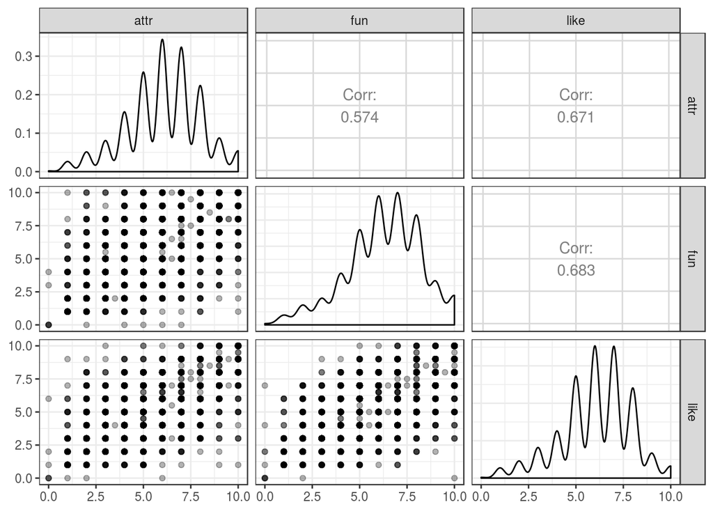

```r
dados %>%
  select(attr, fun, like) %>%
  ggpairs(lower = list(continuous = wrap("points", alpha = 0.3)))
```

Já é possivel perceber, a partir do gráfico acima, que tanto a váriável *fun* (divertido) quanto a variável *attr* (atraente), apresentam correlações positivas com a variável *like* (gostar), com 0.683 e 0.671, respectivamente.

Para responder a pergunta, vamos usar regressão. Também vamos considerar a variável *like* como sendo a variável resposta. Vamos criar um modelo de *linke* em função *fun* e *attr*:

```r
model.encontros_relampagos = lm(like ~ fun + attr, data = dados)

dados_aux = dados %>%
  add_predictions(model.encontros_relampagos) %>%
  add_residuals(model.encontros_relampagos)
```

Agora, vamos analisar os resíduos do modelo criado para as váriáveis *fun* e *attr*.  
- Para a variável *fun*, temos:

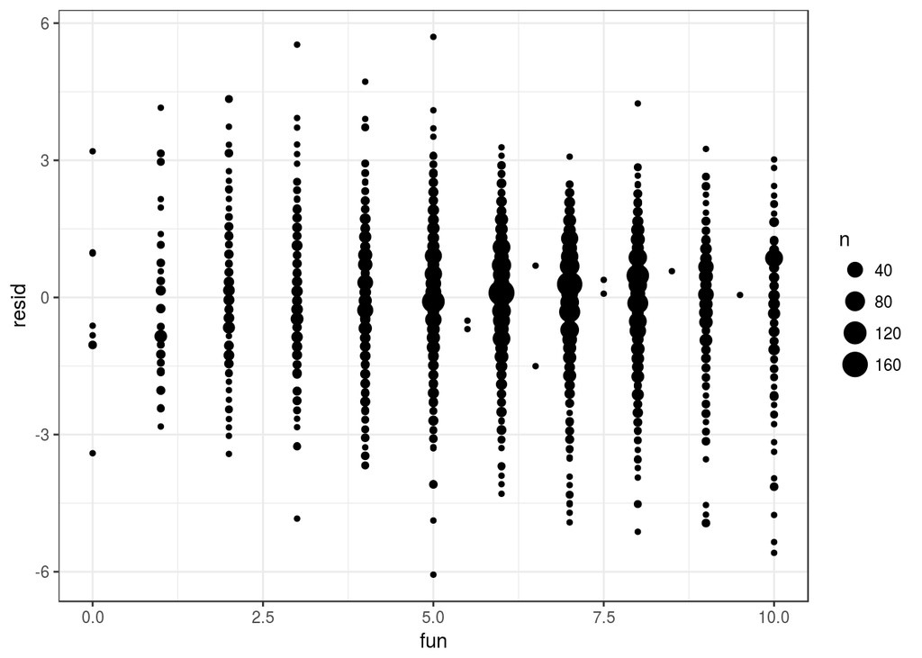

```r
dados_aux %>%
  ggplot(aes(x = fun)) +
  geom_count(aes(y = resid))
```

A partir dos resíduos da variável *fun* é possível perceber que a maioria está concentrado entre -4 e 4, existindo algumas amostras que estão foram deste intervalo, mas eu concluo que, no geral, o modelo parece descrever bem os dados, pelo menos para a variável *fun*.

- Para a variável *attr*, temos:

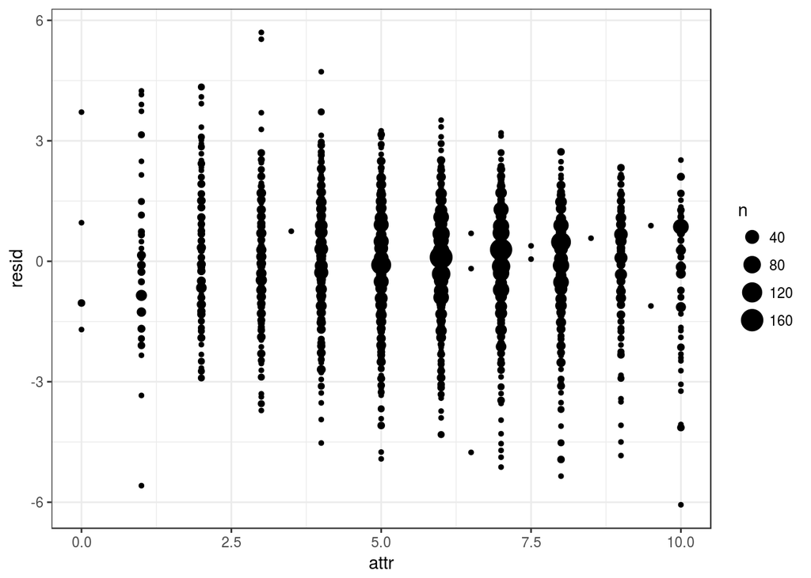

```r
dados_aux %>%
  ggplot(aes(x = attr)) +
  geom_count(aes(y = resid))
```

A partir dos resíduos da variável *attr*, assim como na variável *fun*, é possível perceber que a maioria está concentrado entre -4 e 4, existindo algumas amostras que estão foram deste intervalo, mas eu também concluo que, no geral, o modelo parece descrever bem os dados, pelo menos para a variável *attr*.

Como o nosso modelo é *like* em função de *attr* e *fun*, podemos escrevê-lo como forma de função, obviamente, a partir dos coeficientes abaixo:

```r
tidy(model.encontros_relampagos, conf.int = TRUE)
```

```
##          term  estimate  std.error statistic       p.value  conf.low
## 1 (Intercept) 1.0391152 0.06416500  16.19442  1.931667e-57 0.9133217
## 2         fun 0.4153587 0.01073226  38.70190 1.095440e-284 0.3943184
## 3        attr 0.3948057 0.01094067  36.08607 6.266414e-252 0.3733569
##   conf.high
## 1 1.1649087
## 2 0.4363989
## 3 0.4162546
```

A função do modelo é: $like = 1.039 + (0.415 * fun) + (0.394 * attr)$ Logo, podemos perceber que a cada valor a mais em *fun*, é acrescido 0.415 em *like* e a cada valor a mais em *attr* é acrescido 0.394 em *like*. Isso quer dizer que quanto mais divertido e/ou atraente uma pessoa é, mais a outra gostará dela.

Vamos agora, observar o nosso modelo:

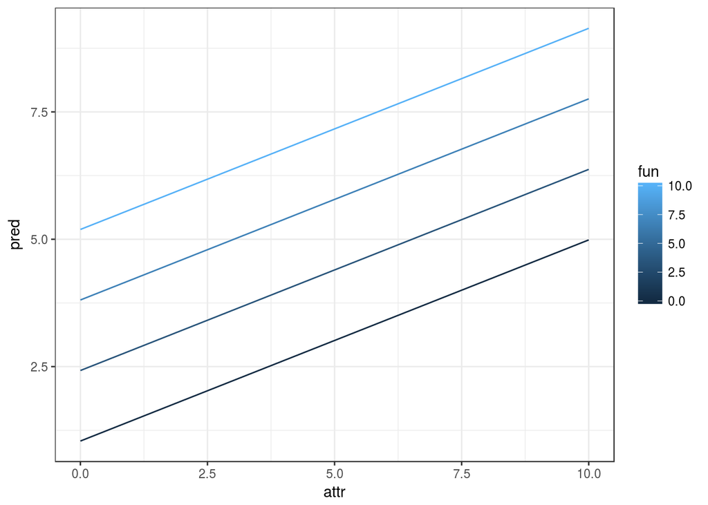

```r
dados_plot = dados %>%
  data_grid(attr = seq_range(attr, 10),
            fun = seq_range(fun, 4)) %>%
  add_predictions(model.encontros_relampagos)

dados_plot %>%
  ggplot(aes(x = attr, y = pred)) +
  geom_line(aes(group = fun, colour = fun))
```

O modelo acima, nos ajuda a entender melhor o nosso modelo, observando os valores preditos ( *like* ) em função de *fun* e *attr*, que são as variáveis independentes.

# A pergunta anterior foi considerando ambos os gêneros, Será que as respostas acima continuam as mesmas quando considerarmos apenas as avaliações das mulheres?

Primeiramente, para responder a esta questão, vamos usar apenas os dados das mulheres:

```r
dados_mulheres = dados %>%
  filter(gender == 0 , gender != 'NA')
```

Vamos analisar o comportamento das correlações entre as variáveis nas amostras de mulheres:

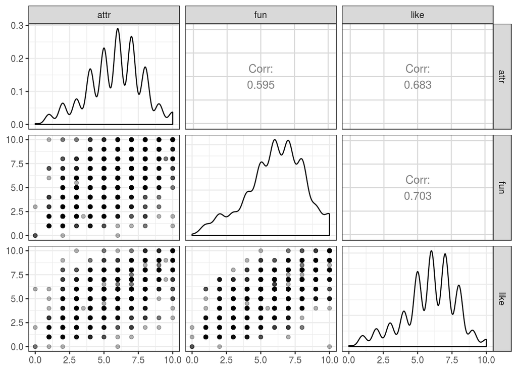

```r
dados_mulheres %>%
  select(attr, fun, like) %>%
  ggpairs(lower = list(continuous = wrap("points", alpha = 0.3)))
```

Podemos percever que as correlações ainda continuam fortes e positivas, mas agora percebe-se que as correlações aumentaram. Observamos que, a partir do gráfico acima, tanto a váriável *fun* (divertido) quanto a variável *attr* (atraente), apresentam correlações positivas com a variável *like* (gostar), com 0.703 e 0.683, respectivamente.

Agora, vamos criar o nosso modelo…

```r
model.encontros_relampagos_mulheres = lm(like ~ fun + attr, data = dados_mulheres)

dados_mulheres_aux = dados_mulheres %>%
  add_predictions(model.encontros_relampagos_mulheres) %>%
  add_residuals(model.encontros_relampagos_mulheres)
```

Agora, vamos analisar os resíduos do modelo criado para as váriáveis *fun* e *attr*.  
- Para a variável *fun*, temos:

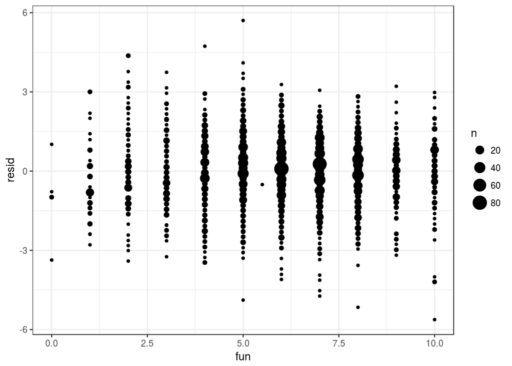

```r
dados_mulheres_aux %>%
  ggplot(aes(x = fun)) +
  geom_count(aes(y = resid))
```

- Para a variável *attr*, temos:

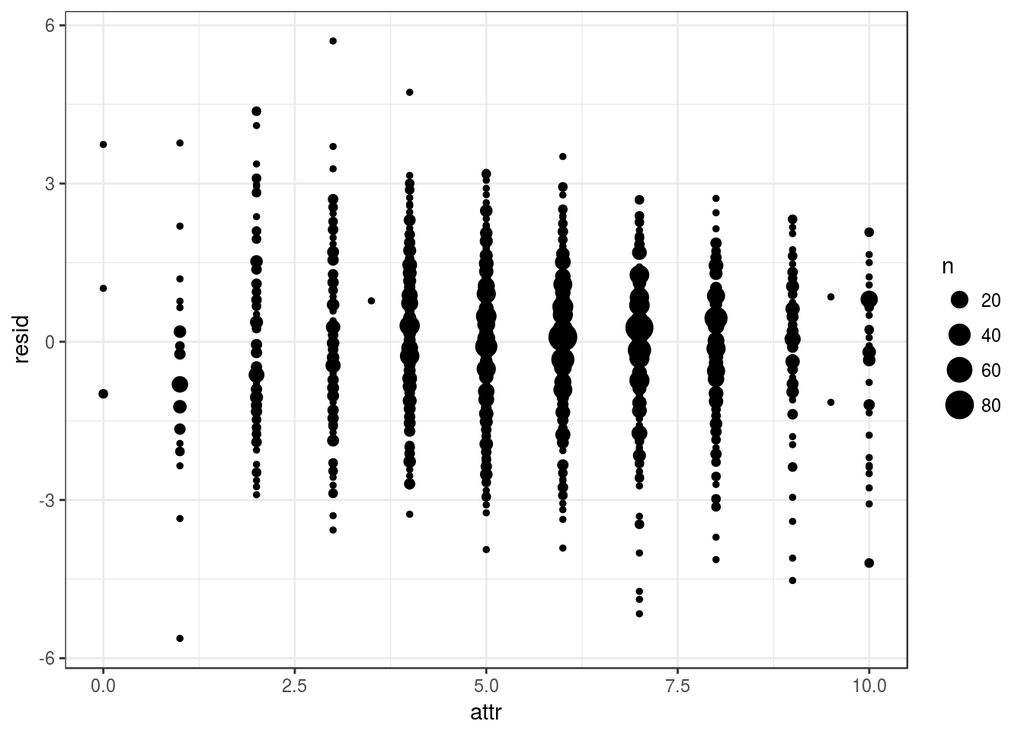

```r
dados_mulheres_aux %>%
  ggplot(aes(x = attr)) +
  geom_count(aes(y = resid))
```

Analisando os resíduos das variáveis, a partir dos gráficos acima, percebemos a maioria das amostras estão concentradas entre -4 e 4. Dessa forma, podemos concluir que, no geral, o modelo parece descreber bem os dados, para ambas as variáveis ( *fun* e *attr*).

Escrevendo o nosso modelo como uma função:

```r
tidy(model.encontros_relampagos_mulheres, conf.int = TRUE)
```

```
##          term  estimate  std.error statistic       p.value  conf.low
## 1 (Intercept) 0.9870784 0.08549891  11.54492  4.959528e-30 0.8194174
## 2         fun 0.4240447 0.01491893  28.42326 4.920129e-153 0.3947890
## 3        attr 0.3967818 0.01562141  25.39986 5.467561e-126 0.3661486
##   conf.high
## 1 1.1547394
## 2 0.4533003
## 3 0.4274149
```

A função do modelo é: $like = 0.987 + (0.424 * fun) + (0.396 * attr)$ Logo, podemos perceber que a cada valor a mais em *fun*, é acrescido 0.424 em *like* e a cada valor a mais em *attr* é acrescido 0.396 em *like*. Isso quer dizer que quanto mais divertido e/ou atraente uma pessoa é, mais a outra gostará dela.

Vamos agora, observar o nosso modelo:

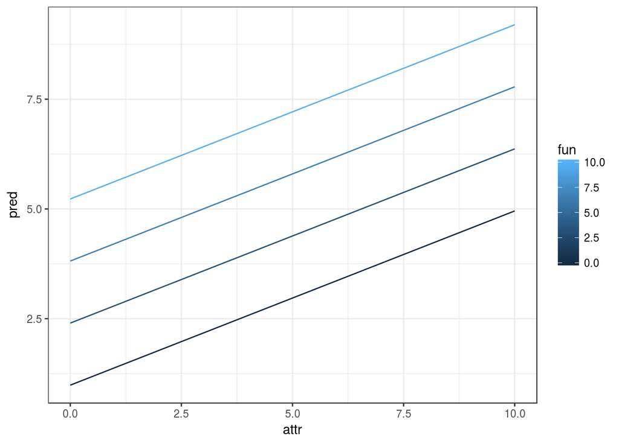

```r
dados_plot_mulheres = dados_mulheres %>%
  data_grid(attr = seq_range(attr, 10),
            fun = seq_range(fun, 4)) %>%
  add_predictions(model.encontros_relampagos_mulheres)

dados_plot_mulheres %>%
  ggplot(aes(x = attr, y = pred)) +
  geom_line(aes(group = fun, colour = fun))
```

Observando o modelo acima e os resíduos, chegamos a conclusão que a resposta permannece a mesmo considerando apenas as amostras das mulheres.